# Week8-Lab VII

Aamol Gote

10/18/2019

```r
download.file("http://www.openintro.org/stat/data/mlb11.RData", destfile = "mlb11.RData")
load("mlb11.RData")
```

```r
nrow(mlb11)
```

```
## [1] 30
```

**Excercise 1**

What type of plot would you use to display the relationship between runs and one of the other numerical variables? Plot this relationship using the variable at_bats as the predictor. Does the relationship look linear? If you knew a team’s at_bats, would you be comfortable using a linear model to predict the number of runs?

Scatterplot would be used to display the relationship between runs and one of the other Numerical variables

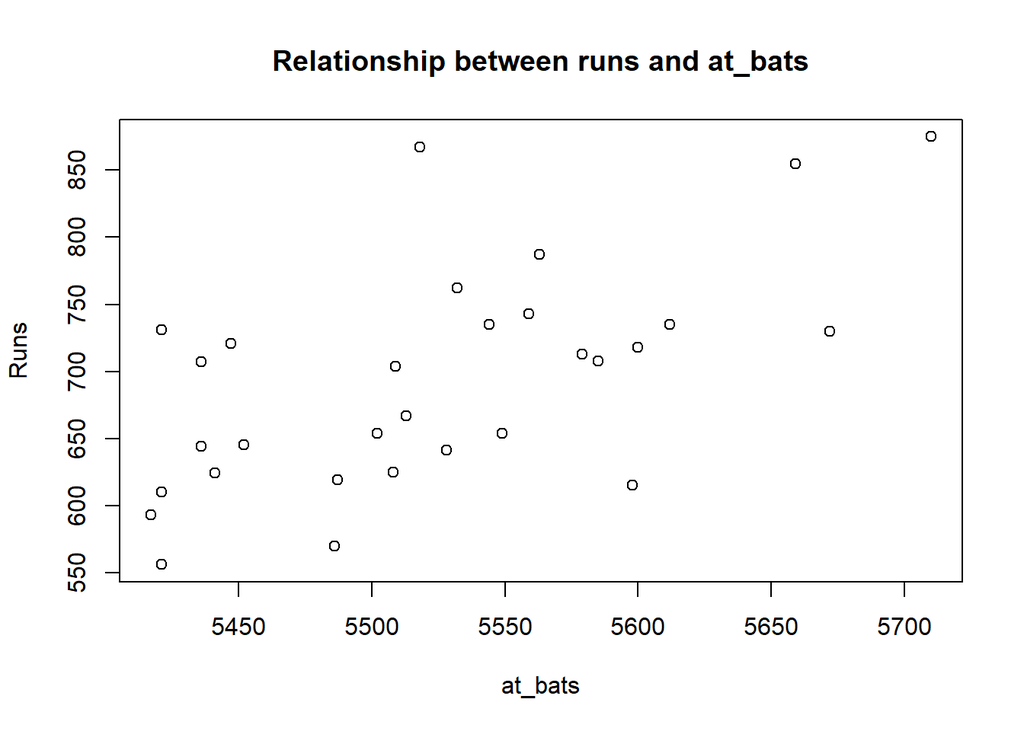

```r
plot(mlb11$at_bats, mlb11$runs, main = "Relationship between runs and at_bats", xlab = "at_bats", ylab = "Runs")
```

Relationship between runs and at_bats is linear, but relationship is not strong relationship and it seems to be moderate one.

We can quantify the relationship between runs and at_bats using correlation coefficient

```r
cor(mlb11$at_bats, mlb11$runs)
```

```
## [1] 0.610627
```

Team’s at_bats can be used in a linear model to predict the number of runs given that we could see some linear trend in relationship. But, the relationship is not strong enough, so the prediction may not be of desired accuracy

**Excercise 2**

Looking at your plot from the previous exercise, describe the relationship between these two variables. Make sure to discuss the form, direction, and strength of the relationship as well as any unusual observations.

1. Relationship between runs and at_bats is positively correlated, as at_bats increases runs also increases.
2. Relationship is not strong but moderatly stronger.
3. There are few outliars like at_bats > 5650 as well runs near 850
4. There’s no curvature to the plot, so this is a linear relationship.

**Excercise 3**

Using plot_ss, choose a line that does a good job of minimizing the sum of squares. Run the function several times. What was the smallest sum of squares that you got? How does it compare to your neighbors?

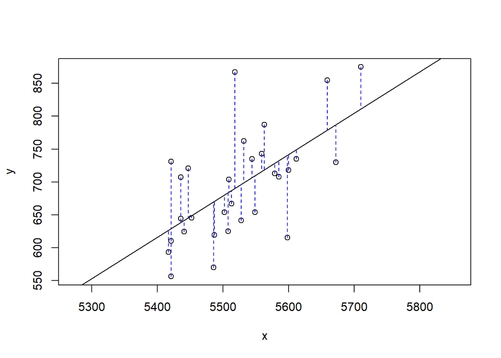

```
## Click two points to make a line.

## Call:
## lm(formula = y ~ x, data = pts)
##
## Coefficients:
## (Intercept)            x
##  -2789.2429       0.6305
##
## Sum of Squares:  123721.9
```

```r
plot_ss(x = mlb11$at_bats, y = mlb11$runs)
```

Smallest Sum of squares: 123721.9

The neighboring value deviate from the smallest value by around 4000 - 5000.

==============================================

```r
m1 <- lm(runs ~ at_bats, data = mlb11)
summary(m1)
```

```
##
## Call:
## lm(formula = runs ~ at_bats, data = mlb11)
##
## Residuals:
##     Min      1Q  Median      3Q     Max
## -125.58  -47.05  -16.59   54.40  176.87
##
## Coefficients:
##               Estimate Std. Error t value Pr(>|t|)
## (Intercept) -2789.2429   853.6957  -3.267 0.002871 **
## at_bats         0.6305     0.1545   4.080 0.000339 ***
## ---
## Signif. codes:  0 '***' 0.001 '**' 0.01 '*' 0.05 '.' 0.1 ' ' 1
##
## Residual standard error: 66.47 on 28 degrees of freedom
## Multiple R-squared:  0.3729, Adjusted R-squared:  0.3505
## F-statistic: 16.65 on 1 and 28 DF,  p-value: 0.0003388
```

**Excercise 4**

Fit a new model that uses homeruns to predict runs. Using the estimates from the R output, write the equation of the regression line. What does the slope tell us in the context of the relationship between success of a team and its home runs?

```r
m1 <- lm(runs ~ homeruns, data = mlb11)
summary(m1)
```

```
##
## Call:
## lm(formula = runs ~ homeruns, data = mlb11)
##
## Residuals:
##     Min      1Q  Median      3Q     Max
## -91.615 -33.410   3.231  24.292 104.631
##
## Coefficients:
##             Estimate Std. Error t value Pr(>|t|)
## (Intercept) 415.2389    41.6779   9.963 1.04e-10 ***
## homeruns      1.8345     0.2677   6.854 1.90e-07 ***
## ---
## Signif. codes:  0 '***' 0.001 '**' 0.01 '*' 0.05 '.' 0.1 ' ' 1
##
## Residual standard error: 51.29 on 28 degrees of freedom
## Multiple R-squared:  0.6266, Adjusted R-squared:  0.6132
## F-statistic: 46.98 on 1 and 28 DF,  p-value: 1.9e-07
```

Equation of regression line

y = b0 + b1x

runs = 415.2389 + 1.8345 * homeruns

In the context of the relationship between success of a team and its home runs slope tells that for every home run, number of total runs will also increase 1.8345.

Slope = 1.8345

```r
cor(mlb11$runs, mlb11$homeruns)
```

```
## [1] 0.7915577
```

Positive relationship with a correlation coefficient of 0.7915577, which is on stronger side (relatively stronger).

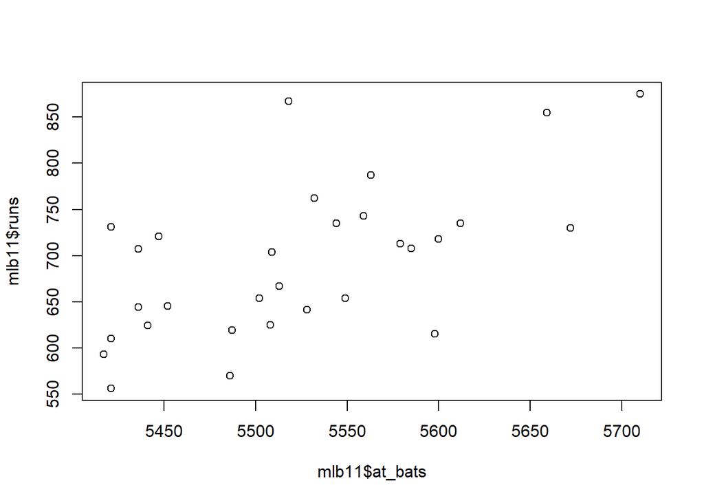

```r
plot(mlb11$runs ~ mlb11$at_bats)
abline(m1)
```

**Excercise 5**

If a team manager saw the least squares regression line and not the actual data, how many runs would he or she predict for a team with 5,578 at-bats? Is this an overestimate or an underestimate, and by how much? In other words, what is the residual for this prediction?

```r
m1 <- lm(runs ~ at_bats, data = mlb11)
summary(m1)
```

```
##
## Call:
## lm(formula = runs ~ at_bats, data = mlb11)
##
## Residuals:
##     Min      1Q  Median      3Q     Max
## -125.58  -47.05  -16.59   54.40  176.87
##
## Coefficients:
##               Estimate Std. Error t value Pr(>|t|)
## (Intercept) -2789.2429   853.6957  -3.267 0.002871 **
## at_bats         0.6305     0.1545   4.080 0.000339 ***
## ---
## Signif. codes:  0 '***' 0.001 '**' 0.01 '*' 0.05 '.' 0.1 ' ' 1
##
## Residual standard error: 66.47 on 28 degrees of freedom
## Multiple R-squared:  0.3729, Adjusted R-squared:  0.3505
## F-statistic: 16.65 on 1 and 28 DF,  p-value: 0.0003388
```

Least Square Regression line for runs vs at_bats

y = b0 + b1x

b0 = -2789.2429 b1 = 0.6305;

x = 5578 (at_bats)

y = -2789.2429 + 0.6305 * (5578)

y =727.6861

Predicted runs (y) = 728

Estimated number of runs for 5578 at bats based on the linear regression formula above is 728.

Based on below data there are no teams with at_bats = 5578, nearest match is at_bats = 5579 for **Philadelphia Phillies** with runs **713**. So going by this there is an overestimate of 728 - 713 = 15 runs.

Residual of the prediction is 15

```r
mlb11[order(mlb11$runs,mlb11$at_bats),]
```

```
##                     team runs at_bats hits homeruns bat_avg strikeouts
## 30      Seattle Mariners  556    5421 1263      109   0.233       1280
## 28  San Francisco Giants  570    5486 1327      121   0.242       1122
## 29      San Diego Padres  593    5417 1284       91   0.237       1320
## 23    Pittsburgh Pirates  610    5421 1325      107   0.244       1308
## 10        Houston Astros  615    5598 1442       95   0.258       1164
## 21       Minnesota Twins  619    5487 1357      103   0.247       1048
## 27  Washington Nationals  624    5441 1319      154   0.242       1323
## 22       Florida Marlins  625    5508 1358      149   0.247       1244
## 26        Atlanta Braves  641    5528 1345      173   0.243       1260
## 12   Los Angeles Dodgers  644    5436 1395      117   0.257       1087
## 24     Oakland Athletics  645    5452 1330      114   0.244       1094
## 17     Chicago White Sox  654    5502 1387      154   0.252        989
## 13          Chicago Cubs  654    5549 1423      148   0.256       1202
## 15    Los Angeles Angels  667    5513 1394      155   0.253       1086
```

[output cut: 47 more lines]

=================

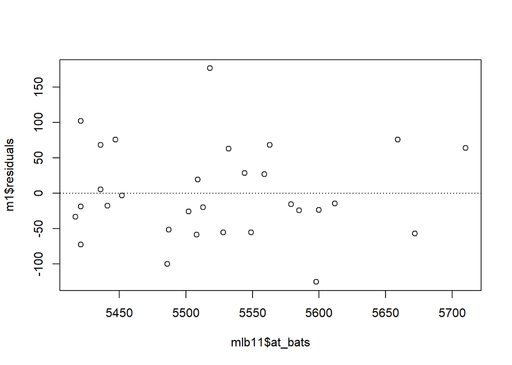

```r
plot(m1$residuals ~ mlb11$at_bats)
abline(h = 0, lty = 3)
```

**Excercise 6**

Is there any apparent pattern in the residuals plot? What does this indicate about the linearity of the relationship between runs and at-bats?

There is no apparent pattern in the residual plot.

Distribution is scattered all over. It does indicate linear relationship between runs and at_bats.